# Forecasting Electricity Demand

- Show All Code
- Hide All Code
- View Source

A worked case study in time-series forecasting, with a real generation-mix leakage trap

Author

Tran Nguyen Vu

Published

September 30, 2026

**Interactive application**

[Open the Streamlit app](https://energy-demand-forecasting.streamlit.app)

## 1 Introduction

This project predicts hourly electricity demand (`Consumption`, megawatts) for Romania's national grid, using published data from 2019 onward together with its generation mix (nuclear, wind, hydro, oil & gas, coal, solar, biomass). Demand is a **time series**: observations are ordered in time, so evaluation must preserve that order to avoid leaking future information into training.

The generation-mix breakdown makes it possible to test whether recent production patterns carry forecasting signal and to examine changes in Romania's renewable electricity production.

One thing worth flagging upfront: **this dataset is live and continuously updated** — checked directly, an earlier download had 46,002 rows through April 2024, the version used here has 62,810 rows through March 2026, with older rows unchanged. Every number below reflects one snapshot, not a fixed, versioned file.

## 2 Data

```python
from energy_demand_forecasting import config, data

df = data.load_raw()
print(f"{len(df)} rows, {df[config.DATETIME_COL].min()} to {df[config.DATETIME_COL].max()}")
```

```
62810 rows, 2019-01-01 00:00:00 to 2026-03-14 23:00:00
```

### 2.1 Two real data-quality issues — and they are not the same issue

```python
dupes = df[df[config.DATETIME_COL].duplicated(keep=False)]
full_range = pd.date_range(df[config.DATETIME_COL].min(), df[config.DATETIME_COL].max(), freq="h")
missing = full_range.difference(df[config.DATETIME_COL])
print(f"{len(dupes)} duplicate timestamps, {len(missing)} missing timestamps")

gaps = data.gap_lengths(df)
print(f"{len(gaps)} separate gaps, longest: {gaps.max()} hours")
```

```
18 duplicate timestamps, 321 missing timestamps
78 separate gaps, longest: 83 hours
```

```python
frame = data.load_clean_frame()
print(f"{len(frame)} hours, strictly regular: {(frame.index.to_series().diff().dropna() == pd.Timedelta(hours=1)).all()}")
```

```
63120 hours, strictly regular: True
```

### 2.2 Exploring the series and its generation mix

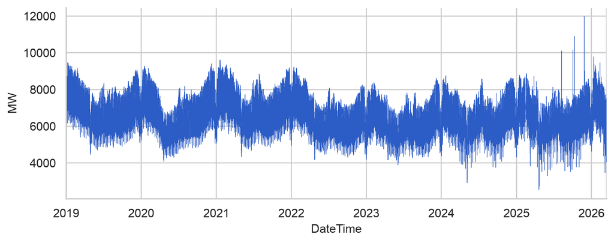

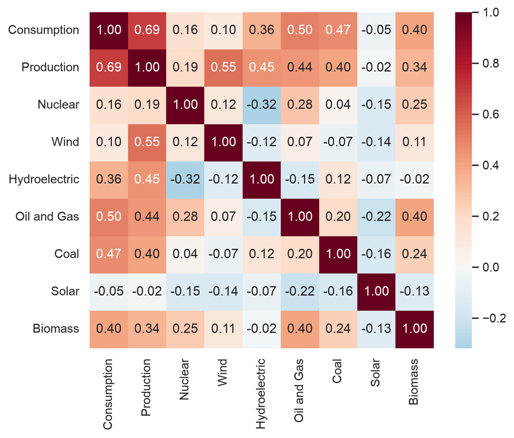

```python
fig, ax = plt.subplots(figsize=(9, 3.2))
frame[config.TARGET_COL].plot(ax=ax, linewidth=0.4, color=PALETTE[0])
ax.set_ylabel("MW")
plt.show()

corr = frame.corr()
fig, ax = plt.subplots(figsize=(7, 5.5))
sns.heatmap(corr, annot=True, fmt=".2f", cmap="RdBu_r", center=0, ax=ax)
plt.show()
```

`Consumption` correlates most with `Production` (0.69, as expected) and the two dispatchable fossil sources, `Oil and Gas` (0.50) and `Coal` (0.47) — the grid operator leans on fossil generation specifically to follow demand swings. `Solar` is essentially uncorrelated with demand (-0.05), which is exactly what I’d expect: solar output follows daylight and weather, not consumption.

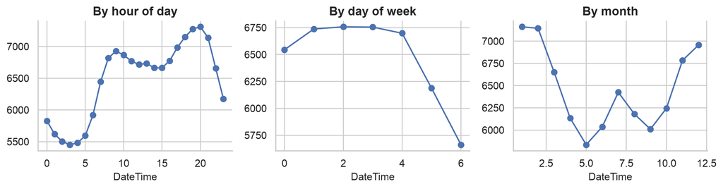

```python
fig, axes = plt.subplots(1, 3, figsize=(11, 3.0))
frame.groupby(frame.index.hour)[config.TARGET_COL].mean().plot(ax=axes[0], marker="o", title="By hour of day")
frame.groupby(frame.index.dayofweek)[config.TARGET_COL].mean().plot(ax=axes[1], marker="o", title="By day of week")
frame.groupby(frame.index.month)[config.TARGET_COL].mean().plot(ax=axes[2], marker="o", title="By month")
plt.tight_layout()
plt.show()
```

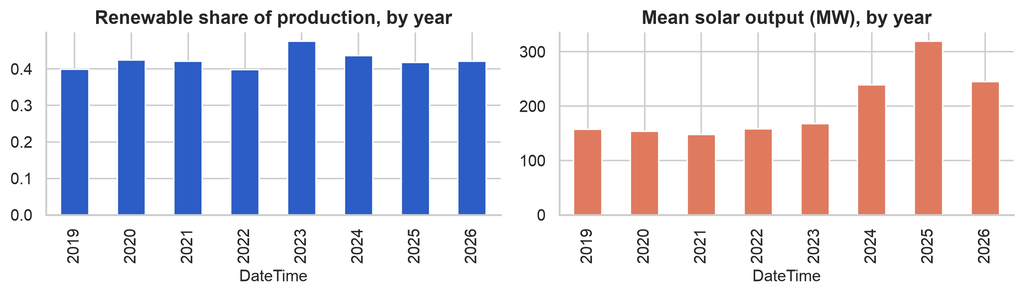

```python
renewable_share = frame[config.RENEWABLE_COLS].sum(axis=1) / frame["Production"]
fig, axes = plt.subplots(1, 2, figsize=(10, 3.0))
renewable_share.groupby(frame.index.year).mean().plot.bar(ax=axes[0], title="Renewable share of production, by year", color=PALETTE[0])
frame.groupby(frame.index.year)["Solar"].mean().plot.bar(ax=axes[1], title="Mean solar output (MW), by year", color=PALETTE[3])
plt.tight_layout()
plt.show()
```

The clearest “genuinely useful and interesting” finding from having the generation-mix breakdown at all: renewable share has held around 40-48% of production every year since 2019, but **mean solar output roughly doubled between 2023 (~168 MW) and 2025 (~319 MW)** — a real, checkable signature of Romania’s recent solar buildout.

## 3 Statistical rigor before modeling

### 3.1 Is this series stationary?

```python
from energy_demand_forecasting import model

adf_result = model.stationarity_test(frame[config.TARGET_COL])
print(f"ADF statistic: {adf_result['statistic']:.2f}, p-value: {adf_result['p_value']:.4g}")
```

```
ADF statistic: -14.38, p-value: 9.086e-27
```

Formally stationary (no unit root) — which looked wrong to me at first given the obvious daily/monthly patterns above. The resolution: ADF specifically tests for a *stochastic trend*, not for seasonality. A strong, bounded, repeating pattern always reverts toward its typical shape rather than wandering further from it, so it doesn’t have a unit root even though it clearly isn’t “flat.”

### 3.2 Autocorrelation, used to justify lag choices empirically

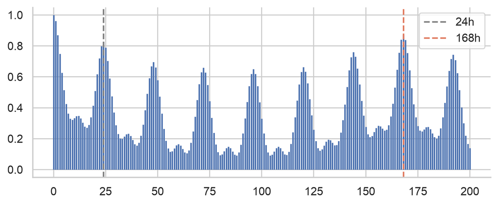

```
ACF at lag 1h: 0.9614
ACF at lag 24h: 0.8267
ACF at lag 48h: 0.6955
ACF at lag 168h: 0.8730
```

```python
acf_values = model.autocorrelation(frame[config.TARGET_COL], n_lags=200)
fig, ax = plt.subplots(figsize=(8, 3.0))
ax.stem(range(len(acf_values)), acf_values, markerfmt=" ", basefmt=" ")
ax.axvline(24, linestyle="--", color="gray", label="24h")
ax.axvline(168, linestyle="--", color=PALETTE[3], label="168h")
ax.legend()
plt.show()
for lag in [1, 24, 48, 168]:
    print(f"ACF at lag {lag}h: {acf_values[lag]:.4f}")
```

Autocorrelation is genuinely high at both 24h (0.83) and 168h (0.87 — if anything slightly stronger), with a noticeably weaker mid-point at 48h (0.70) — empirical justification for these two specific lags, rather than picking them by convention.

## 4 Feature engineering

### 4.1 The leakage trap in the generation-mix columns

`Production` and its 7 source breakdowns are recorded at the **same hour** as `Consumption`, not before it. Using them directly would be circular for a real forecasting task, since generation is dispatched in response to demand, not fixed in advance. Every generation-mix feature is lagged by 24 hours.

```python
from energy_demand_forecasting import features

seasonal_lookup = features.fit_seasonal_lookup(frame[config.TARGET_COL].iloc[: int(len(frame) * 0.85)])
X, y = features.split_features_target(frame, seasonal_lookup=seasonal_lookup)
X[["lag_24h", "lag_168h", "Solar_lag_24h", "net_export_lag_24h", "renewable_share_lag_24h"]].tail(3)
```

| DateTime | lag_24h | lag_168h | Solar_lag_24h | net_export_lag_24h | renewable_share_lag_24h |
| --- | --- | --- | --- | --- | --- |
| 2026-03-14 21:00:00 | 7041.0 | 6402.0 | 0.0 | -185.0 | 0.441219 |
| 2026-03-14 22:00:00 | 6426.0 | 6234.0 | 0.0 | 115.0 | 0.415839 |
| 2026-03-14 23:00:00 | 6019.0 | 5777.0 | 0.0 | 348.0 | 0.394220 |

### 4.2 A leakage-safe way to reuse a seasonal-decomposition idea

A natural next step is decomposing the series into trend/seasonal/ residual components and adding them as features. Doing this the most direct way — fitting `statsmodels`’ decomposition on the whole series before splitting — leaks: the trend component is a **centered** moving average using points both before *and after* each timestamp, so fitting it on the full series means training features are quietly built with future test-period information. `fit_seasonal_lookup` fits the decomposition **only on the training split** and reuses just the strictly periodic seasonal component (24 fixed hour-of-day offsets, safe to reapply to any timestamp without recomputation).

```python
X_train, X_test, y_train, y_test = model.chronological_train_test_split(X, y)
pipe_with = model.build_pipeline(model.lightgbm_estimator())
pipe_with.fit(X_train, y_train)
scores_with = model.regression_scores(y_test, pipe_with.predict(X_test))

X_without, y_without = features.split_features_target(frame)
X_train_wo, X_test_wo, y_train_wo, y_test_wo = model.chronological_train_test_split(X_without, y_without)
pipe_without = model.build_pipeline(model.lightgbm_estimator())
pipe_without.fit(X_train_wo, y_train_wo)
scores_without = model.regression_scores(y_test_wo, pipe_without.predict(X_test_wo))

print("WITH seasonal_24h:   ", {k: round(v, 4) for k, v in scores_with.items()})
print("WITHOUT seasonal_24h:", {k: round(v, 4) for k, v in scores_without.items()})
```

```
WITH seasonal_24h:    {'mae': 259.0764, 'rmse': 423.3834, 'mape': 0.0428}
WITHOUT seasonal_24h: {'mae': 258.6064, 'rmse': 424.0605, 'mape': 0.0428}
```

An honest negative result: adding the seasonal-decomposition feature makes essentially no difference (identical MAPE to 4 decimal places). LightGBM’s tree splits likely already extract everything useful from the cyclical `hour_sin`/`hour_cos` encoding plus the lag/rolling features — worth reporting the idea that didn’t help, not only the ones that did.

## 5 Methodology

### 5.1 Why the train/test split is chronological, not shuffled

Lag and rolling-window features are built from each row’s own recent past, so a random shuffle would leak near-future information into training rows sitting next to shuffled-in test rows. The split is by position along the time-sorted index (last 15% of hours as test), and cross-validation uses `TimeSeriesSplit`, never `KFold`.

### 5.2 A naive baseline, measured before trusting any model

```python
baseline_scores = model.naive_seasonal_baseline(X_test_wo, y_test_wo)
print({k: round(v, 4) for k, v in baseline_scores.items()})
```

```
{'mae': 469.9865, 'rmse': 743.9772, 'mape': 0.078}
```

“Same hour last week” is off by **~7.8%** on average (MAPE) — note this test period includes some of the messy, interpolated 2024-2025 outage stretches, so this baseline is measured under harder conditions than 2019-2023 alone would give.

### 5.3 Model comparison, via TimeSeriesSplit

```python
cv_results = []
for name, factory in model.MODEL_FACTORIES.items():
    scores = model.cross_validate_pipeline(X_without, y_without, estimator=factory(), cv=5)
    cv_results.append({"model": name, **scores})
cv_df = pd.DataFrame(cv_results).sort_values("mape_mean")
cv_df[["model", "mae_mean", "rmse_mean", "mape_mean", "mape_std"]]
```

|  | model | mae_mean | rmse_mean | mape_mean | mape_std |
| --- | --- | --- | --- | --- | --- |
| 2 | LightGBM | 201.451715 | 296.578291 | 0.032711 | 0.007269 |
| 1 | Random Forest | 217.293322 | 331.002114 | 0.035472 | 0.008034 |
| 0 | Linear Regression | 246.806452 | 348.224245 | 0.039196 | 0.007359 |
| 3 | MLP (neural network) | 409.488313 | 533.091900 | 0.063881 | 0.052476 |

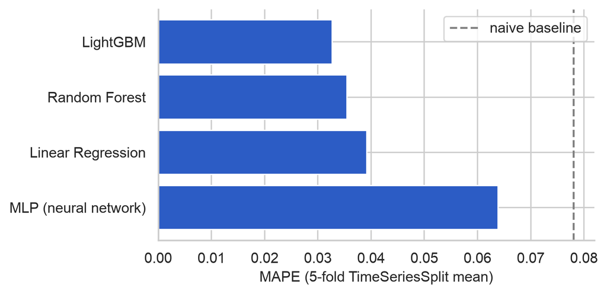

```python
fig, ax = plt.subplots(figsize=(6, 3.2))
ax.barh(cv_df["model"], cv_df["mape_mean"], color=PALETTE[0])
ax.axvline(baseline_scores["mape"], linestyle="--", color="gray", label="naive baseline")
ax.set_xlabel("MAPE (5-fold TimeSeriesSplit mean)")
ax.legend()
plt.gca().invert_yaxis()
plt.show()
```

## 6 Final chronological holdout

```python
final_pipeline = model.train_pipeline(X_train_wo, y_train_wo, estimator=model.lightgbm_estimator())
test_preds = final_pipeline.predict(X_test_wo)
print({k: round(v, 4) for k, v in model.regression_scores(y_test_wo, test_preds).items()})
```

```
{'mae': 258.6064, 'rmse': 424.0605, 'mape': 0.0428}
```

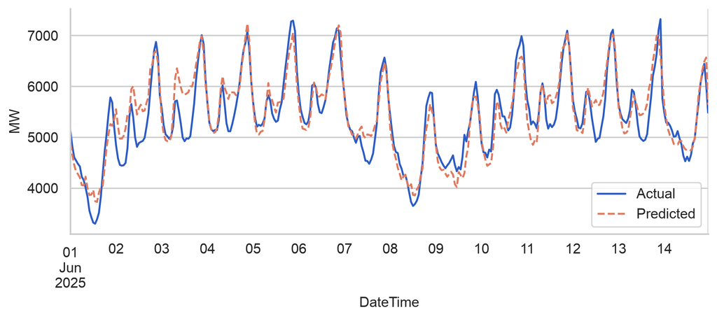

```python
fig, ax = plt.subplots(figsize=(9, 3.2))
sample_start, sample_end = "2025-06-01", "2025-06-14"
y_test_wo.loc[sample_start:sample_end].plot(ax=ax, label="Actual", color=PALETTE[0])
pd.Series(test_preds, index=y_test_wo.index).loc[sample_start:sample_end].plot(ax=ax, label="Predicted", linestyle="--", color=PALETTE[3])
ax.set_ylabel("MW")
ax.legend()
plt.show()
```

## 7 Model interpretability

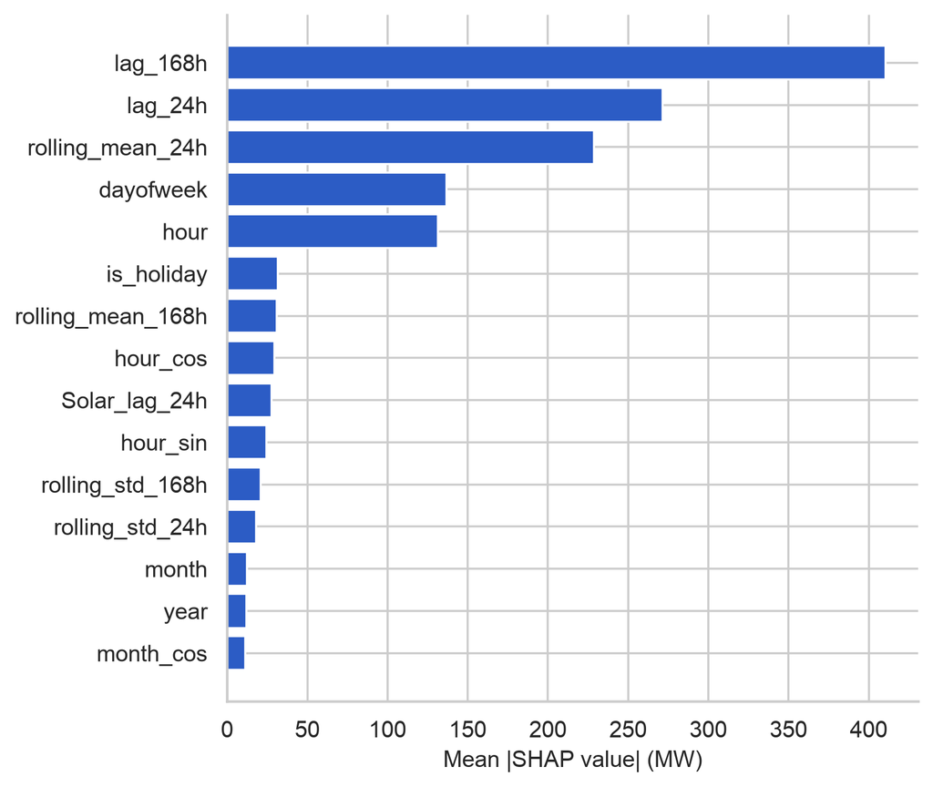

```python
from energy_demand_forecasting.interpretability import compute_shap_values, top_shap_features

explanation, X_transformed = compute_shap_values(final_pipeline, X_without, max_samples=500)
top = top_shap_features(explanation, top_n=15).sort_values("mean_abs_shap")

fig, ax = plt.subplots(figsize=(6, 6))
ax.barh(top["feature"], top["mean_abs_shap"], color=PALETTE[0])
ax.set_xlabel("Mean |SHAP value| (MW)")
plt.show()
```

## 8 Discussion: limitations and future work

- **This dataset is live and not fully reproducible.** Every number above reflects one snapshot; a fresh download adds rows, so the quoted row counts and test-set contents are tied to this download.
- **Outage gaps require approximate reconstruction.** An 83-hour linear interpolation cannot recover real demand swings. Evaluation touching these gaps uses partly reconstructed observations.
- **Weather is not observed directly.** Calendar features capture seasonal patterns but cannot represent individual temperature changes. Adding weather observations could improve forecasts.
- **Results apply to Romania's grid and the evaluated period.** Changes in demand, generation capacity, or market conditions may require retraining and renewed chronological evaluation.
- **The role of lagged solar output needs further investigation.** Its SHAP ranking suggests predictive value but does not establish a causal relationship with consumption.

## 9 Conclusion

Romania's hourly consumption-and-production data supports demand forecasting while exposing practical modeling challenges: generation features must be lagged to avoid leakage, and multi-hour outage gaps need to be distinguished from routine DST artifacts.

LightGBM outperformed the regression, Random Forest, and neural-network baselines in this evaluation. The seasonal-decomposition feature added no measurable benefit after leakage checks, while yesterday's solar output ranked highly in the model explanation. These findings support the value of chronological evaluation, explicit baselines, and careful feature engineering, while leaving the solar proxy effect as an open question.